# check_double_strand

## Identifying transcripts that can form double strand RNAs

Three scenarios that meet our interest in the formation of dsRNAs in cytosol:

- antisense transcripts paired with the exons of a gene in the opposite strand
- anti-sense transcripts paired with exons of nearby genes
- paired genes with overlapped exons

Review of antisense transcription: https://www.nature.com/articles/nrm2738

- The most prominent form of antisense transcription is AS-noncoding paired with protein coding transcripts.

Reich et al. 2019 mapping the dsRNA world The observation of ADAR editing sites in an endogenous RNA is proof that the RNA is double-stranded in vivo, a gold standard used not only in determining dsRNAomes, but also as proof for specific dsRNA structures (Sijen and Plasterk 2003).

## Procedure

Given a list of query genes and a GRange object for GENCODE genomic annotations,

1. partition the GRange object into two subsets
   - a subset with transcripts of query genes
   - a subset with exons and UTR of all genes
2. identify any overlapping pair out of the two subset GRange objects
   - 50 base pairs as the the minimum length of base pairing
3. filter out any pairs located on the same strand

## Validate with labeled antisense transcripts from previous GENCODE release

523 out of 814 (64%) antisense genes found in the current GENCODE release were identified to span exons or UTR regions of any genes on the opposite strand.

A data.frame: 1 × 3

| matchedAS <int> | knownAS <int> | prop <dbl> |
| --- | --- | --- |
| 523 | 814 | 0.64 |

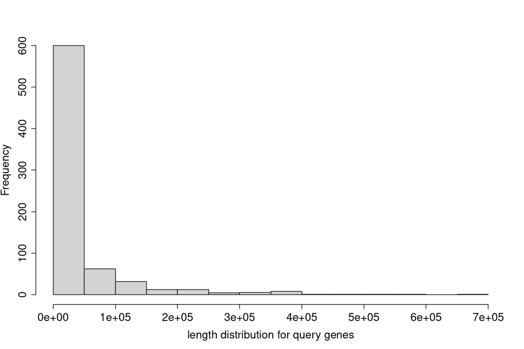

## Validate with the three pairs of cis-NATs tested in Qin Li's nature paper

Three pairs of cis-NATs in the paper:

- CTSA:PLTP
- TNFRSF14:TNFRSF14-AS1
- HBP1:COG5

[figure not shown]

### Validate with reported antisense transcripts and their targets in the review paper

A grouped_df: 10 × 3

| queryTranscript.gene_name <chr> | ref.gene_name <chr> | targets.gene_name <chr> |
| --- | --- | --- |
| PINK1 | PINK1-AS | naPINK1 |
| SIX3 | SIX3-AS1 | Six3OS |
| VAX2 | ENSG00000258881 | Vax2OS |
| VAX2 | ATP6V1B1-AS1 | Vax2OS |
| ZEB2 | ZEB2-AS1 | Zeb2 NAT |
| MKRN2 | MKRN2OS | RAF1 |
| MKRN2 | RAF1 | RAF1 |
| SMAD5 | SMAD5-AS1 | DAMS |
| CDYL | CDYL-AS1 | CDYL-AS |
| EMX2 | EMX2OS | EMX2OS |

The list of reported antisense-target pairs have different gene names, so I don't have a good way to compare the results yet.

'19 out of 32 genes in GENCODE database were found to form dsRNAs.'

## Testing on TWAS prioritized genes with two approaches

Regardless of traits, 82 of all the prioritized genes from TWAS were identified to potentially form dsRNAs. The top TWAS gene *MAPKAPK5-AS1* was found in the list.

### Examine whether dsRNA transcripts have m6A peaks nearby?

```r
#m6A peak length distribution
quantile(as.numeric(peaks$end) - as.numeric(peaks$start))
```

**0%**

49

**25%**

248

**50%**

491

**75%**

1777

**100%**

85731

```
[1] "82 TWAS genes nearby dsRNAs predicted with antisense approach:"
```

1. 'EIF2B2'

2. 'ERCC1'

3. 'FDPS'

4. 'TRAF3IP3'

5. 'ADCY7'

6. 'AKAP8'

7. 'AP4B1'

8. 'TXNDC11'

9. 'THAP3'

10. 'GNL3'

11. 'NEK4'

12. 'NDUFA2'

13. 'ATG13'

14. 'PSKH1'

15. 'ACADVL'

16. 'RAI1'

17. 'IRF3'

18. 'DIS3L2'

19. 'NCAPG'

20. 'TRAM2'

21. 'GNA12'

22. 'TES'

23. 'HNRNPK'

24. 'DIABLO'

25. 'MAX'

26. 'ZFYVE26'

27. 'ZNF839'

28. 'AKTIP'

29. 'DHX38'

30. 'SPG7'

31. 'CEP250'

32. 'MADD'

33. 'MAPKAPK5-AS1'

34. 'TRAF4'

35. 'ERAL1'

36. 'LDLR'

37. 'VGLL4'

38. 'PCSK7'

39. 'DENND3'

40. 'WAC-AS1'

41. 'DDX55'

42. 'RABEP1'

43. 'SLC9A3R1'

44. 'FIGNL1'

45. 'SENP1'

46. 'MDM2'

47. 'CYB5D1'

48. 'PFAS'

49. 'CALR'

50. 'HM13'

51. 'BET1L'

52. 'MVK'

53. 'RBM23'

54. 'SLC7A5'

55. 'TAOK1'

56. 'GTPBP2'

57. 'LAMTOR4'

58. 'MEPCE'

59. 'WDR5'

60. 'FERMT3'

61. 'C2CD2L'

62. 'DDHD1'

63. 'SGSM2'

64. 'GIT1'

65. 'CPSF4'

66. 'BCL2L2'

67. 'ARIH2'

68. 'ZER1'

69. 'SMUG1'

70. 'PPP2R3C'

71. 'FBXO34'

72. 'CRTC3'

73. 'RNF40'

74. 'AKAP13'

75. 'CCDC51'

76. 'CD151'

77. 'FANCA'

78. 'ITGB2'

79. 'PRPF38A'

80. 'TRIP12'

81. 'ASCC1'

82. 'TUG1'

```
[1] "9 TWAS genes nearby dsRNA predicted with editing clusters:"
```

1. 'KAT8'

2. 'ICOSLG'

3. 'GMIP'

4. 'WAC-AS1'

5. 'RBM23'

6. 'ARIH2'

7. 'FANCA'

8. 'LAMTOR4'

9. 'NSUN4'

### Directional effects of m6A QTL on targeted genes that have dsRNAs nearby

By only requiring overlapping of m6A sites with any transcript that has antisense genes, more TWAS genes were identified, but the biased effects of m6A QTLs are gone across immune traits.

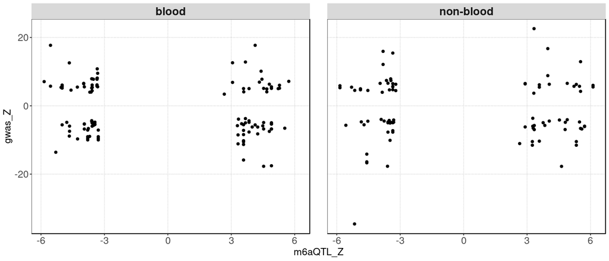

```r
twas_dsRNA[, "trait_type"] <- "blood"
twas_dsRNA$trait_type[twas_dsRNA$trait %in% other_traits]<- "non-blood"
ggplot(data.frame(twas_dsRNA), aes(x = m6aQTL_Z, y = gwas_Z)) +

geom_point() + facet_grid(.~trait_type) +
theme(axis.text=element_text(size=16),
                axis.title=element_text(size=16),
                strip.text.x=element_text(size = 18, face="bold"),
                panel.background = element_rect(fill="white"),
                panel.spacing.x = unit(2, "lines"),
                panel.spacing.y = unit(1, "lines"),
                panel.grid.major.y=element_line(colour="grey", linetype = "dotted"),
                panel.grid.major.x=element_line(colour="grey", linetype = "dotted"),
                panel.border = element_rect(fill = NA,
                                            colour = "black"))
```

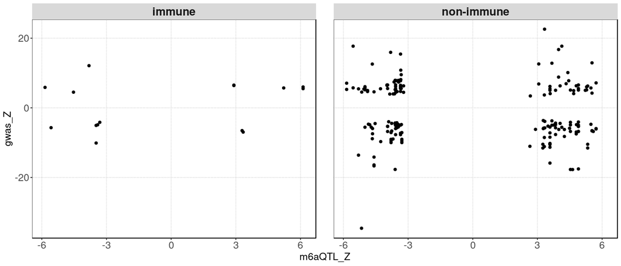

```r
twas_sub<-twas_dsRNA[twas_dsRNA$trait_type == "immune", ]
model <-lm(twas_sub$gwas_Z ~ twas_sub$m6aQTL_Z)
summary(model)
```

```
Call:
lm(formula = twas_sub$gwas_Z ~ twas_sub$m6aQTL_Z)

Residuals:
   Min     1Q Median     3Q    Max
-9.491 -4.359  2.479  4.657 12.854

Coefficients:
                  Estimate Std. Error t value Pr(>|t|)
(Intercept)         0.7041     1.7989   0.391    0.702
twas_sub$m6aQTL_Z   0.3802     0.4104   0.926    0.371

Residual standard error: 6.957 on 13 degrees of freedom
Multiple R-squared:  0.06193,	Adjusted R-squared:  -0.01023
F-statistic: 0.8582 on 1 and 13 DF,  p-value: 0.3711
```

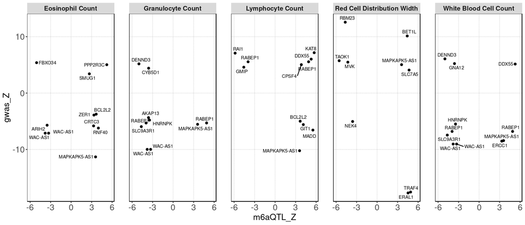

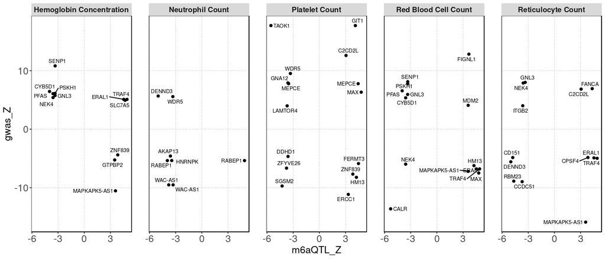

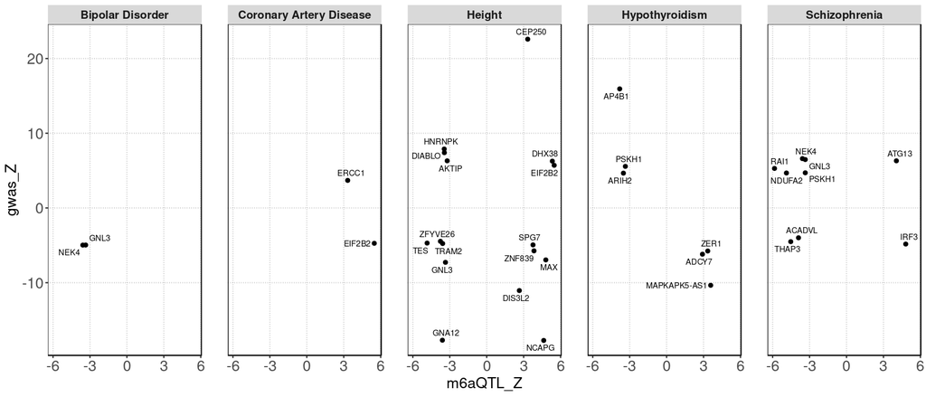

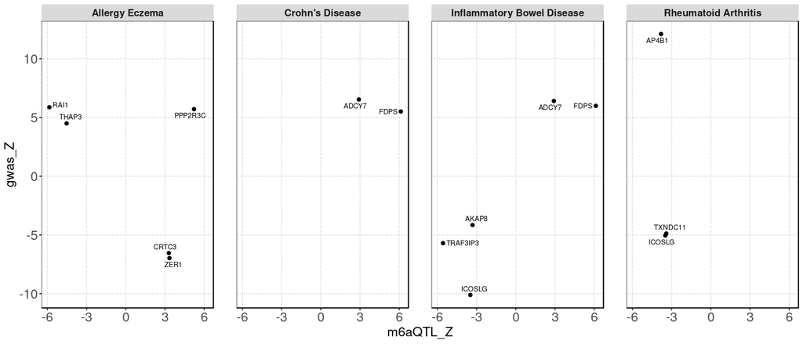

### Repeat the analysis with genes that show evidence of colocalization

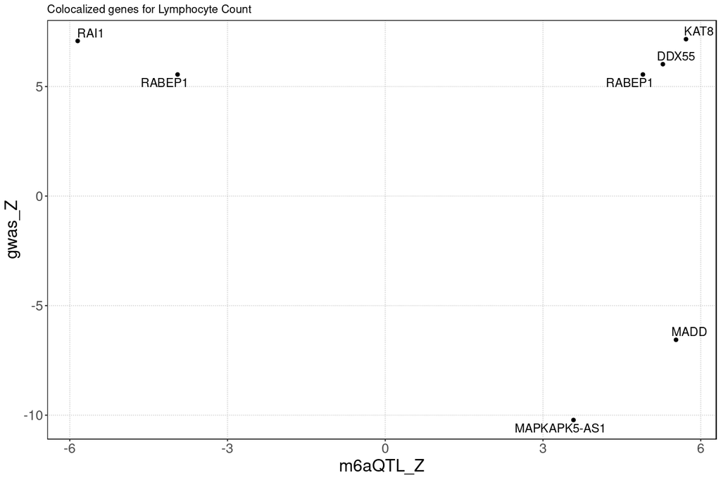

**Overlapped distances between m6A peaks and dsRNAs**

We consider the flanking regions of m6A peaks, which is +/-250 bp from the two ends of the peaks.

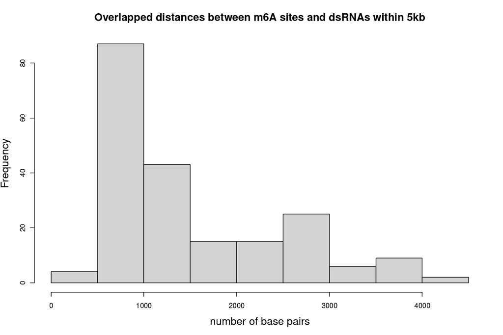

### Enrichment for dsRNA genes among TWAS prioritized genes

```
[1] "The total number prioritized TWAS genes potentially form dsRNAs:"
```

82

```
[1] "Proportion of all the genes that can form dsRNAs: "
```

0.32

A data.frame: 6 × 3

|  | num_dsRNA <dbl> | num_TWAS_genes <dbl> | enrichment <dbl> |
| --- | --- | --- | --- |
| Allergy | 0 | 7 | 0.00000 |
| Allergy Eczema | 5 | 20 | 0.78125 |
| Alzheimers | 0 | 1 | 0.00000 |
| Asthma | 0 | 2 | 0.00000 |
| Autoimmune Traits (Sure) | 0 | 1 | 0.00000 |
| Bipolar Disorder | 2 | 2 | 3.12500 |

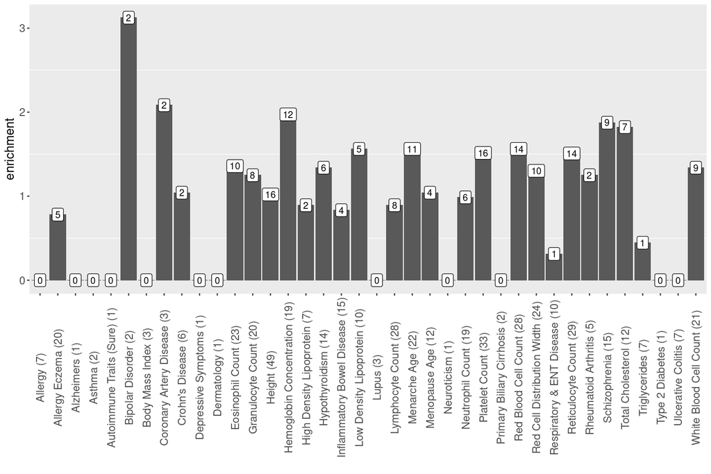

### Length distribution for dsRNA genes

**0%**

1922

**25%**

14182

**50%**

34798

**75%**

67562

**100%**

383106

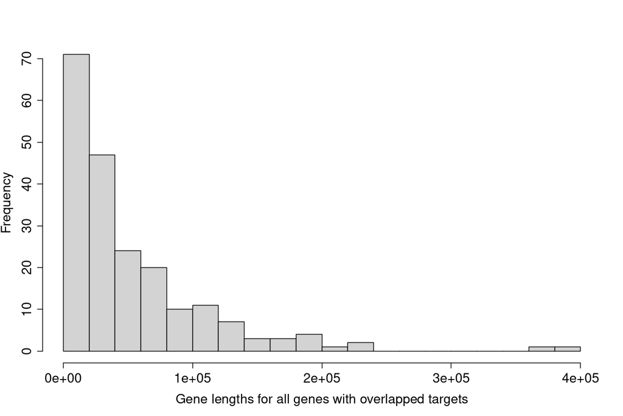

```r
quantile(resultsTWAS$queryL)
hist(resultsTWAS$queryL, main = "", breaks=20,
     xlab = "Gene lengths for all genes with overlapped targets",
     cex = 1.5, cex.axis = 1.5, cex.lab = 1.5)
```

## An alternative approach for dsRNA predictions

### Using genes associated with predicted dsRNAs from the review paper

**Mapping the dsRNA world**

Reich et al. 2019

The review paper defines enriched editing regions (EER) as the window that contains clusters of editing sites. This indicates the presence of long, highly base-paired dsRNA. With their EER-detecting pipelines, around 3400 EER transcripts were identified using RNA-seq data from human blood monocytes. They also validated those regions with RNA secondary structure prediction algorithms to confirm whether they are more structured than random controls. When filtered by predicted folding free energy per nucleotide to be negative, 2759 genes remain to be associated with EERs.

### Distribution for the predicted folding free energy per nucleotide

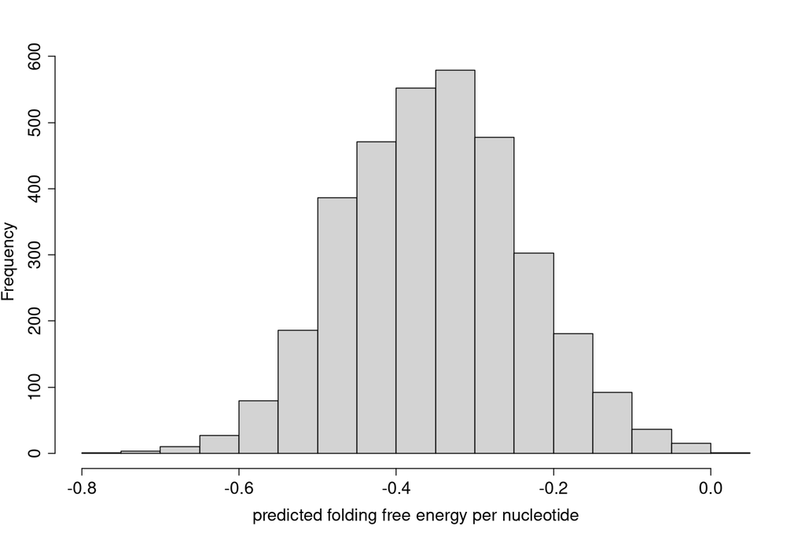

```r
head(overlaps)
```

```
DataFrame with 6 rows and 9 columns
                         gr        gene   m6aQTL_ID  m6aQTL_Z
                  <GRanges> <character> <character> <numeric>
1 chr16:31128534-31138618:+        KAT8   rs4527034      5.72
2 chr16:31128534-31138618:+        KAT8   rs4527034      5.72
3 chr21:45642428-45647025:-      ICOSLG   rs2070554     -3.48
4 chr21:45642428-45647025:-      ICOSLG   rs2070554     -3.48
5 chr19:19739832-19745177:-        GMIP    rs873870     -4.58
6 chr19:19739832-19745177:-        GMIP    rs873870     -4.58
                   trait     gwas_ID    gwas_Z                 gr.double
             <character> <character> <numeric>                 <GRanges>
1        Body Mass Index    rs749767    -6.079 chr16:31132570-31135107:+
2        Body Mass Index    rs749767    -6.079 chr16:31127726-31128688:-
3 Inflammatory Bowel D..   rs2838520   -10.110 chr21:45643735-45644567:-
4   Rheumatoid Arthritis   rs4819388    -5.050 chr21:45643735-45644567:-
5 Low Density Lipoprot..  rs16996148   -14.150 chr19:19741468-19744826:-
6      Total Cholesterol  rs16996148   -16.690 chr19:19741468-19744826:-
    gene_name
  <character>
1        KAT8
2           .
3      ICOSLG
4      ICOSLG
5       LPAR2
6       LPAR2
```

### Enrichment of TWAS genes predicted to form dsRNA

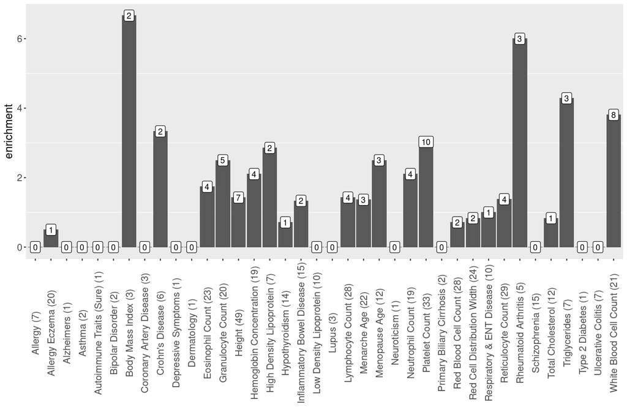

**A summary table for TWAS prioritized genes with at least 2 fold of enrichment**

A data.frame: 46 × 2

|  | trait <chr> | dsRNA_genes <chr> |
| --- | --- | --- |
| 1 | Body Mass Index | TRUB2 |
| 2 | Body Mass Index | KAT8 |
| 5 | Rheumatoid Arthritis | RUFY3 |
| 6 | Rheumatoid Arthritis | TXNDC11 |
| 7 | Rheumatoid Arthritis | ICOSLG |
| 15 | Crohn's Disease | GON4L |
| 16 | Crohn's Disease | ICOSLG |
| 17 | High Density Lipoprotein | TGOLN2 |
| 18 | High Density Lipoprotein | BAZ1B |
| 20 | Triglycerides | BAZ1B |
| 21 | Triglycerides | PCSK7 |
| 22 | Triglycerides | KAT8 |
| 23 | White Blood Cell Count | THEMIS2 |
| 24 | White Blood Cell Count | GNA12 |
| 25 | White Blood Cell Count | DENND3 |
| 26 | White Blood Cell Count | WAC-AS1 |
| 27 | White Blood Cell Count | DDX55 |
| 28 | White Blood Cell Count | PHF11 |
| 29 | White Blood Cell Count | RABEP1 |
| 30 | White Blood Cell Count | SLC9A3R1 |
| 35 | Hemoglobin Concentration | GTPBP2 |
| 36 | Hemoglobin Concentration | ZNF839 |
| 37 | Hemoglobin Concentration | SLC7A5 |
| 38 | Hemoglobin Concentration | SMG9 |
| 39 | Platelet Count | THEMIS2 |
| 40 | Platelet Count | GNA12 |
| 41 | Platelet Count | OGDH |
| 42 | Platelet Count | BAZ1B |
| 43 | Platelet Count | LAMTOR4 |
| 44 | Platelet Count | MEPCE |
| 45 | Platelet Count | FERMT3 |
| 46 | Platelet Count | NEAT1 |
| 47 | Platelet Count | ZNF839 |
| 48 | Platelet Count | HM13 |
| 57 | Granulocyte Count | TGOLN2 |
| 58 | Granulocyte Count | DENND3 |
| 59 | Granulocyte Count | WAC-AS1 |
| 60 | Granulocyte Count | RABEP1 |
| 61 | Granulocyte Count | SLC9A3R1 |
| 62 | Neutrophil Count | TGOLN2 |
| 63 | Neutrophil Count | DENND3 |
| 64 | Neutrophil Count | WAC-AS1 |
| 65 | Neutrophil Count | RABEP1 |
| 76 | Menopause Age | NSUN4 |
| 77 | Menopause Age | MEPCE |
| 78 | Menopause Age | RABEP1 |

### Directional effects of m6A QTL on genes associated with dsRNA

No clear patterns of directional effects were found with m6A QTLs when comparing dsRNA-associate TWAS genes and the rest.

```r
colnames(twas)
```

1. 'Trait'

2. 'GENE'

3. 'm6A.PEAK.ID'

4. 'CHR'

5. 'HSQ'

6. 'BEST.GWAS.ID'

7. 'BEST.GWAS.Z'

8. 'm6AQTL.ID'

9. 'm6AQTL.R2'

10. 'm6AQTL.Z'

11. 'm6AQTL.GWAS.Z'

12. 'N.SNP'

13. 'MODEL'

14. 'MODELCV.R2'

15. 'MODELCV.PV'

16. 'TWAS.Z'

17. 'TWAS.P'

18. 'TWAS.P.Bonferroni'

19. 'dsRNA'

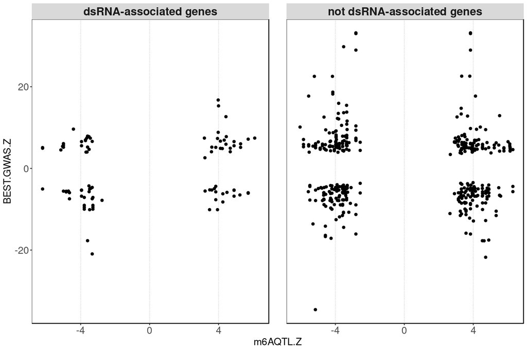